# Site Occupancy Putois

08/08

## 0.1 Intallation des packages

```r
library(dplyr);library(ggplot2);library(sf);library(unmarked)
theme_set(theme_light(base_size = 16))
set.seed(1234)
```

## 0.2 Importation des bases de donnees

```r
Total <- sf::st_read(paste0(wd$data, "derived/Total.shp"),
                     options = "ENCODING=UTF8")
```

```
## options:        ENCODING=UTF8
```

```r
Total <- Total%>%
  transform_Total()

VariablesSite <- sf::st_read(paste0(wd$data, "derived/VariablesSite.shp"),
                             options = "ENCODING=UTF8")
```

```
## options:        ENCODING=UTF8
```

```r
VariablesSite <- VariablesSite%>%
  transform_VarSites()
```

```r
Putois <- Total %>%
  sf::st_join(VariablesSite) %>%
  dplyr::filter(cd_nom == 60731,
                technique_observation == "Vu",
                date >= as.Date("2005-01-01")) %>%
  # select(-c(insee_dept, lib_dept, lib_dept, FID, surf, CD_SIG)) %>%
  dplyr::select(-nom_valide, -nom_vernaculaire, -ordre, -technique_observation) %>%
  dplyr::mutate(year = lubridate::year(date))
```

## 0.3 Creation de la base de donnee Detection - Non Detection

```r
detection_df <- Putois %>%
  sf::st_drop_geometry() %>%
  dplyr::mutate(annee = lubridate::year(date)) %>%
  dplyr::select(Code_10km, annee) %>%
  dplyr::count(Code_10km, annee) %>%
  tidyr::complete(Code_10km,
                  annee = tidyr::full_seq(annee, 1),
                  fill = list(n = 0)) %>%
  tidyr::pivot_wider(names_from = annee,
                     values_from = n) %>%
  dplyr::arrange(Code_10km) %>%
  dplyr::filter(!is.na(Code_10km))

detection_df[,-1] <- ifelse(detection_df[,-1]>0, 1, 0)

noms <- detection_df$Code_10km
detection_matrice <- as.matrix(detection_df[, -1])
rownames(detection_matrice) <- noms
```

## 0.4 Covariables de site

```r
site_info <- VariablesSite %>%
  sf::st_drop_geometry() %>%
  dplyr::arrange(Code_10km)

noms <- site_info$Code_10km
rownames(site_info) <- noms

site_info <- site_info %>%
  dplyr::select(-Code_10km) %>%
  dplyr::rename(Dnst_Cultures = `Dnst_Cultures `)%>%
  dplyr::mutate(across(where(is.numeric),
                       scale))
```

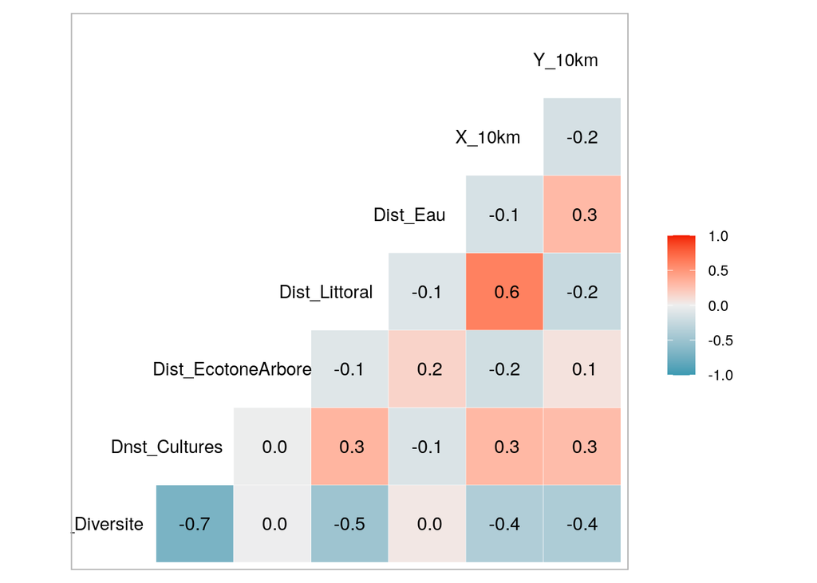

```r
site_info %>%
  dplyr::select(-air_km2) %>%
  dplyr::select_if(is.numeric) %>%
  GGally::ggcorr(label = TRUE, hjust = 0.75)
```

```r
names(site_info)
```

```
##  [1] "Ind_Diversite"      "Dnst_Cultures"      "Dist_EcotoneArbore" "Dist_Littoral"
##  [5] "Dist_Eau"           "Famille_paysage"    "Nom_paysage"        "air_km2"
##  [9] "X_10km"             "Y_10km"
```

```r
df <- site_info%>%
  rename(X10km = X_10km,
         Y10km = Y_10km) %>%
  dplyr:: select(-air_km2) %>%
  dplyr::select_if(is.numeric)
df <- as.data.frame(lapply(df, as.numeric))
```

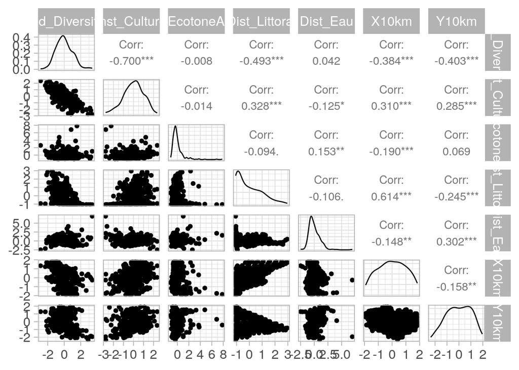

```r
GGally::ggpairs(as.data.frame(lapply(df, as.numeric)))
```

On voit dans ces graphiques une forte correlation lineaire entre la densite de cultures et l’indice de diversite. On remarque aussi une correlation lineaire entre X et la distance au littoral. Graphiquement, on ne voit pas forcement de correlation particuliers de correlation dans les nuage de points, apart X et Y dans contre la distance au littoral, mais c’est pas forcement un probleme.

Comme ils le font dans l’etude avec les ours, on va se se retirer les covariables avec une correlation > 0.5 et regarder les diff combinaisons.

## 0.5 Implementation du Model

Mise sous format pour la modelisation

```r
umf <- unmarked::unmarkedFrameOccu(y = detection_matrice,
                                   siteCovs = site_info
                                   )
```

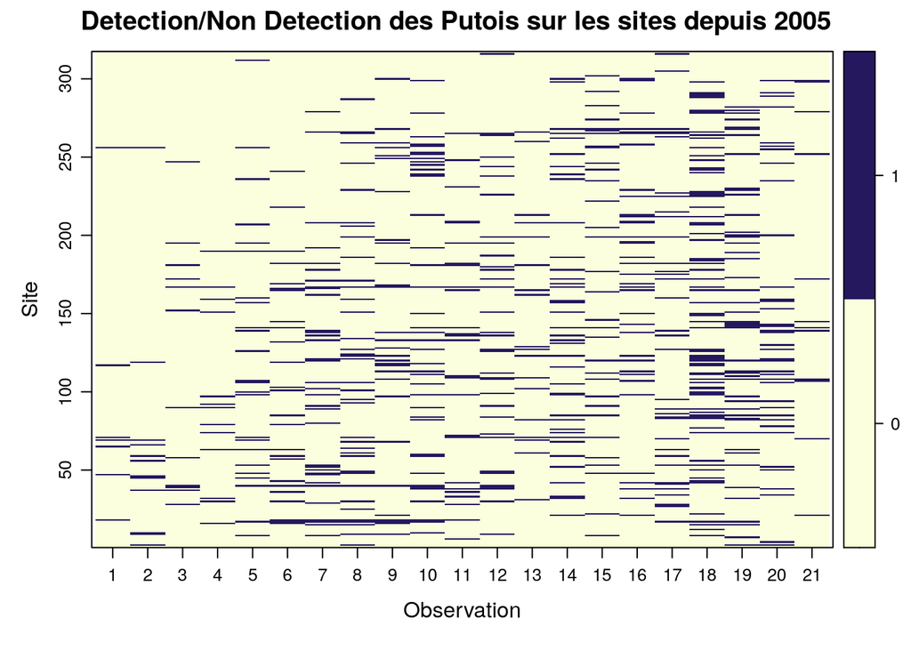

```r
unmarked::plot(umf, main="Detection/Non Detection des Putois sur les sites depuis 2005")
```

Ici on va aussi garder les m?mes periodes (ie enlever 2025 et 2005-2010)

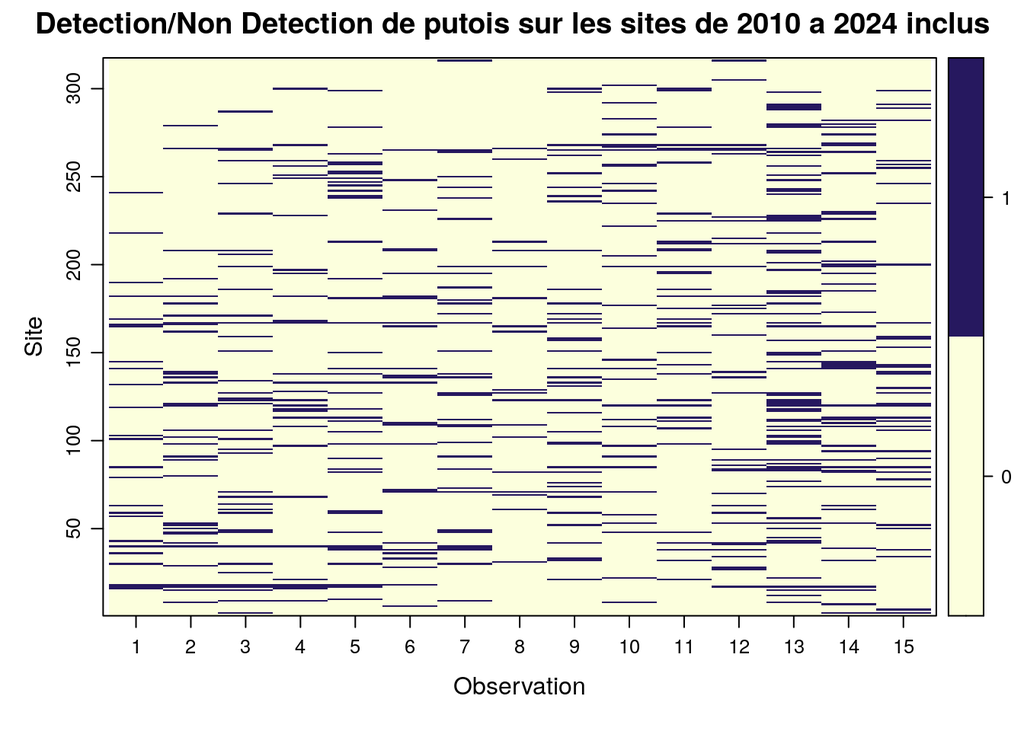

```r
Putoiss <- Total %>%
  sf::st_join(VariablesSite) %>%
  dplyr::filter(cd_nom == 60731,
                technique_observation == "Vu",
                date >= as.Date("2010-01-01"),
                date < as.Date("2025-01-01")) %>%
  # select(-c(insee_dept, lib_dept, lib_dept, FID, surf, CD_SIG)) %>%
  dplyr::select(-nom_valide, -nom_vernaculaire, -ordre, -technique_observation) %>%
  dplyr::mutate(year = lubridate::year(date))

detection_df <- Putoiss %>%
  sf::st_drop_geometry() %>%
  dplyr::mutate(annee = lubridate::year(date)) %>%
  dplyr::select(Code_10km, annee) %>%
  dplyr::count(Code_10km, annee) %>%
  tidyr::complete(Code_10km,
                  annee = tidyr::full_seq(annee, 1),
                  fill = list(n = 0)) %>%
  tidyr::pivot_wider(names_from = annee,
                     values_from = n) %>%
  dplyr::arrange(Code_10km) %>%
  dplyr::filter(!is.na(Code_10km))

detection_df[,-1] <- ifelse(detection_df[,-1]>0, 1, 0)

noms <- detection_df$Code_10km
detection_matrice <- as.matrix(detection_df[, -1])
rownames(detection_matrice) <- noms

umf <- unmarked::unmarkedFrameOccu(y = detection_matrice,
                                   siteCovs = site_info
                                   )

unmarked::plot(umf, main="Detection/Non Detection de putois sur les sites de 2010 a 2024 inclus")
```

```r
summary(umf)
```

```
## unmarkedFrame Object
##
## 317 sites
## Maximum number of observations per site: 15
## Mean number of observations per site: 15
## Sites with at least one detection: 219
##
## Tabulation of y observations:
##    0    1
## 4209  546
##
## Site-level covariates:
##        Ind_Diversite.V1             Dnst_Cultures.V1         Dist_EcotoneArbore.V1
##  Min.   :-2.865708445210000   Min.   :-2.78214762389e+00   Min.   :-1.177548563760
##  1st Qu.:-0.679780380756000   1st Qu.:-6.39147940409e-01   1st Qu.:-0.538861888256
##  Median :-0.103681984768000   Median : 6.52166412662e-02   Median :-0.234385970959
##  Mean   : 0.000000000000001   Mean   : 2.00000000000e-16   Mean   : 0.000000000000
##  3rd Qu.: 0.590728352478000   3rd Qu.: 6.59758341030e-01   3rd Qu.: 0.149328232852
##  Max.   : 3.387273586330000   Max.   : 2.36743641082e+00   Max.   : 7.826110849440
##
##      Dist_Littoral.V1             Dist_Eau.V1                                    Famille_paysage
##  Min.   :-1.070027865720   Min.   :-2.486983274260   Paysage cultive a ragosses          :90
##  1st Qu.:-0.915859784196   1st Qu.:-0.653550370660   Paysage boise et de bosquets        :57
##  Median :-0.266683896501   Median :-0.230018369783   Paysage cultive avec talus          :52
##  Mean   : 0.000000000000   Mean   : 0.000000000000   Paysage de bocage a maille elargie  :41
##  3rd Qu.: 0.699371185739   3rd Qu.: 0.584178367602   Paysage de bocage dense sur collines:34
##  Max.   : 2.957617628370   Max.   : 6.943084217390   Paysage de littoral urbanise        :27
##                                                      (Other)                             :16
##                         Nom_paysage         air_km2.V1                  X_10km.V1
##  Reliefs des Landes de Lanvaux: 36   Min.   :-3.199398376490   Min.   :-1.91668816575e+00
##  Plateau de Penthievre        : 20   1st Qu.: 0.131669308234   1st Qu.:-7.91009617370e-01
##  Bassin de Pontivy-Loudeac    : 18   Median : 0.522356248052   Median : 1.43352452421e-03
##  Armor morbihannais           : 17   Mean   : 0.000000000000   Mean   : 1.00000000000e-16
##  Bassin de Rennes             : 17   3rd Qu.: 0.522356248055   3rd Qu.: 8.11993642375e-01
##  Cornouaille interieure       : 16   Max.   : 0.522356248061   Max.   : 1.82993231695e+00
##  (Other)                      :193
##           Y_10km.V1
##  Min.   :-2.36529227433e+00
##  1st Qu.:-7.80490736624e-01
##  Median : 1.54633653399e-02
##  Mean   : 1.07000000000e-14
##  3rd Qu.: 8.34068493645e-01
##  Max.   : 1.96182815611e+00
##
```

## 0.6 Resultats

Au sein d’une saison, les lapins sont soit present soit absent mais ne changent pas. Entre les saisons, les lapins peuvent coloniser un site (ie: il etiaent pas là avant et mtn ils le sont), ou disparaitre = extinction locale. C’est une chaine de Marcov.

Ici on suppose, qu’il n’y a pas de faux positif.

```r
print(colSums(detection_matrice))
```

```
## 2010 2011 2012 2013 2014 2015 2016 2017 2018 2019 2020 2021 2022 2023 2024
##   25   34   38   29   40   26   34   18   39   32   36   35   74   48   38
```

On dirait que ca augemente apart 2015 - 2016 - 2017, o? on a eu une chute des detections des Putoiss.

```r
M <- nrow(detection_matrice)
numPrimary <- 5

# Example: labeling each season (block)
quali_periodes <- matrix(
  c("2010-2012", "2013-2015", "2016-2018", "2019-2021", "2022-2024"),
  nrow = M, ncol = numPrimary, byrow = TRUE
)

quanti_periodes <- matrix(
  c(1, 2, 3, 4, 5),
  nrow = M, ncol = numPrimary, byrow = TRUE
)

umf <- unmarkedMultFrame(
  y = detection_matrice,
  siteCovs = site_info,
  yearlySiteCovs = list(quali = quali_periodes,
                        quanti = quanti_periodes),
  numPrimary = numPrimary
)
```

# 1 creation des modeles

On essaye plusieurs sans la variance, puis selon l’AIC, on calcule l’AIC a la fin avec le modele qu’on a choisi.

```r
fmList <- unmarked::fitList(fm0, fm1, fm3, fm4, fm5, fm6, fm7)
```

```
## Your list was unnamed, so model names were added automatically
```

```r
unmarked::modSel(fmList)
```

```
## Hessian is singular.
## Hessian is singular.
## Hessian is singular.
## Hessian is singular.
## Hessian is singular.
## Hessian is singular.
## Hessian is singular.
```

```
##     nPars     AIC delta  AICwt cumltvWt
## fm1     5 3260.59  0.00 0.9484     0.95
## fm4     5 3266.86  6.28 0.0411     0.99
## fm3     5 3272.07 11.49 0.0030     0.99
## fm0     4 3272.26 11.68 0.0028     1.00
## fm6     5 3272.77 12.18 0.0021     1.00
## fm7     5 3273.48 12.89 0.0015     1.00
## fm5     5 3274.23 13.64 0.0010     1.00
```

Ici on garde la variable de fm1 ($ \text{Y_10km} $), et on ajoute les autres.

```r
fmList <- unmarked::fitList(fm0, fm1, fm2, fm3, fm4, fm5, fm6)
```

```
## Your list was unnamed, so model names were added automatically
```

```r
unmarked::modSel(fmList)
```

```
## Hessian is singular.
## Hessian is singular.
## Hessian is singular.
## Hessian is singular.
## Hessian is singular.
## Hessian is singular.
```

```
##     nPars     AIC delta   AICwt cumltvWt
## fm1     6 3244.68  0.00 0.99371     0.99
## fm6     6 3256.35 11.66 0.00291     1.00
## fm5     6 3257.04 12.35 0.00206     1.00
## fm3     6 3259.26 14.57 0.00068     1.00
## fm0     5 3260.59 15.90 0.00035     1.00
## fm4     6 3262.17 17.49 0.00016     1.00
## fm2     6 3262.58 17.90 0.00013     1.00
```

Il n’a a que fm1 avec $\delta AIC < 2$ donc on continue pareil:

```r
fm0 <- fm1

fm1 <- unmarked::colext(
  psiformula = ~ Y_10km + X_10km + Dist_Eau,     # initial occupancy
  gammaformula =  ~ 1,  # colonization
  epsilonformula = ~ 1, # extinction
  pformula = ~ 1,  # detection
  data = umf, # data
  control = list(trace = 1),
  se = FALSE)
fm2 <- unmarked::colext(
  psiformula = ~ Y_10km + X_10km + Dist_EcotoneArbore,     # initial occupancy
  gammaformula =  ~ 1,  # colonization
  epsilonformula = ~ 1, # extinction
  pformula = ~ 1,  # detection
  data = umf, # data
  control = list(trace = 1),
  se = FALSE)
fm3 <- unmarked::colext(
  psiformula = ~ Y_10km + X_10km + Dnst_Cultures,     # initial occupancy
  gammaformula =  ~ 1,  # colonization
  epsilonformula = ~ 1, # extinction
  pformula = ~ 1,  # detection
  data = umf, # data
  control = list(trace = 1),
  se = FALSE)
fm4 <- unmarked::colext(
  psiformula = ~ Y_10km + X_10km + Ind_Diversite,     # initial occupancy
  gammaformula =  ~ 1,  # colonization
  epsilonformula = ~ 1, # extinction
  pformula = ~ 1,  # detection
  data = umf, # data
  control = list(trace = 1),
  se = FALSE)
fmList <- unmarked::fitList(
  '{psi(X, Y), p(), gamma(), epsilon()}' = fm0,
  '{psi(X, Y, Dist_Eau), p(), gamma(), epsilon()}' = fm1,
  '{psi(X, Y, , Dist_EcotoneArbore), p(), gamma(), epsilon()}' = fm2,
  '{psi(X, Y, Dnst_Cultures), p(), gamma(), epsilon()}' = fm3,
  '{psi(X, Y, Ind_Diversite), p(), gamma(), epsilon()}' = fm4)
fmList <- unmarked::fitList(fm0, fm1, fm2, fm3, fm4)
```

```
## Your list was unnamed, so model names were added automatically
```

```r
unmarked::modSel(fmList)
```

```
## Hessian is singular.
## Hessian is singular.
## Hessian is singular.
## Hessian is singular.
```

```
##     nPars     AIC delta AICwt cumltvWt
## fm0     6 3244.68  0.00  0.31     0.31
## fm2     7 3244.91  0.23  0.28     0.59
## fm3     7 3245.83  1.15  0.17     0.76
## fm4     7 3246.53  1.85  0.12     0.89
## fm1     7 3246.68  2.00  0.11     1.00
```

On s’arr?te ici car fm0 a le + petit AIC. On va calculer le r?sultats des tests pour les 4 premiers car ce sont ceux ci

## 1.1 Significativit? des variables?

Analyse des r?sultats:

```r
coef_col <- coef(fm0, type = "col")
plogis(coef_col[1]); plogis(coef_col[2]);plogis(coef_col[3]); plogis(coef_col[4])
```

```
##  col(Int)
## 0.2435214
```

```
## <NA>
##   NA
```

```
## <NA>
##   NA
```

```
## <NA>
##   NA
```

```r
coef_ext <- coef(fm0, type = "ext")
plogis(coef_ext[1]); plogis(coef_ext[2]);plogis(coef_ext[3]); plogis(coef_ext[4])
```

```
## ext(Int)
## 0.165264
```

```
## <NA>
##   NA
```

```
## <NA>
##   NA
```

```
## <NA>
##   NA
```

```r
coef_psi <- coef(fm0, type = "psi")
plogis(coef_psi[1]); plogis(coef_psi[2]); plogis(coef_psi[3])
```

```
##  psi(Int)
## 0.4147823
```

```
## psi(Y_10km)
##   0.6267017
```

```
## psi(X_10km)
##   0.3141095
```

```r
unmarked::backTransform(fm0, type="det")
```

```
## Backtransformed linear combination(s) of Detection estimate(s)
##
##  Estimate     SE LinComb (Intercept)
##     0.224 0.0149   -1.24           1
##
## Transformation: logistic
```

```r
summary(fm0)
```

```
##
## Call:
## unmarked::colext(psiformula = ~Y_10km + X_10km, gammaformula = ~1,
##     epsilonformula = ~1, pformula = ~1, data = umf, se = TRUE,
##     control = list(trace = 1))
##
## Initial (logit-scale):
##             Estimate    SE     z  P(>|z|)
## (Intercept)   -0.344 0.205 -1.68 0.093529
## Y_10km         0.518 0.194  2.67 0.007593
## X_10km        -0.781 0.208 -3.75 0.000176
##
## Colonization (logit-scale):
##  Estimate    SE     z  P(>|z|)
##     -1.13 0.153 -7.42 1.21e-13
##
## Extinction (logit-scale):
##  Estimate    SE     z  P(>|z|)
##     -1.62 0.302 -5.36 8.11e-08
##
## Detection (logit-scale):
##  Estimate     SE     z  P(>|z|)
##     -1.24 0.0858 -14.5 1.93e-47
##
## AIC: 3244.681
## Number of sites: 317
```

## 1.2 Tests d’hypotheses

On va commencer par un goodness of fit test

```r
chisq <- function(fm) {
    umf <- fm@data
    y <- umf@y
    y[y>1] <- 1
    fv <- fitted(fm)
    sum((y-fv)^2/(fv*(1-fv)), na.rm=TRUE)
    }

(gof0 <- parboot(fm0, statistic=chisq, nsim=40, parallel=FALSE))
```

```
##
## Call: parboot(object = fm0, statistic = chisq, nsim = 40, parallel = FALSE)
##
## Parametric Bootstrap Statistics:
##     t0 mean(t0 - t_B) StdDev(t0 - t_B) Pr(t_B > t0)
## 1 4601           -147             43.1        0.976
##
## t_B quantiles:
##        0% 2.5%  25%  50%  75% 97.5% 100%
## [1,] 4654 4686 4718 4740 4777  4831 4840
##
## t0 = Original statistic computed from data
## t_B = Vector of bootstrap samples
```

```r
(gof1 <- parboot(fm1, statistic=chisq, nsim=40, parallel=FALSE))
```

```
##
## Call: parboot(object = fm1, statistic = chisq, nsim = 40, parallel = FALSE)
##
## Parametric Bootstrap Statistics:
##     t0 mean(t0 - t_B) StdDev(t0 - t_B) Pr(t_B > t0)
## 1 4601           -155               46        0.976
##
## t_B quantiles:
##        0% 2.5%  25%  50%  75% 97.5% 100%
## [1,] 4623 4676 4729 4754 4783  4835 4876
##
## t0 = Original statistic computed from data
## t_B = Vector of bootstrap samples
```

```r
(gof2 <- parboot(fm2, statistic=chisq, nsim=40, parallel=FALSE))
```

```
##
## Call: parboot(object = fm2, statistic = chisq, nsim = 40, parallel = FALSE)
##
## Parametric Bootstrap Statistics:
##     t0 mean(t0 - t_B) StdDev(t0 - t_B) Pr(t_B > t0)
## 1 4594           -147             53.4        0.976
##
## t_B quantiles:
##        0% 2.5%  25%  50%  75% 97.5% 100%
## [1,] 4646 4653 4702 4734 4784  4816 4885
##
## t0 = Original statistic computed from data
## t_B = Vector of bootstrap samples
```

```r
(gof3 <- parboot(fm3, statistic=chisq, nsim=40, parallel=FALSE))
```

```
##
## Call: parboot(object = fm3, statistic = chisq, nsim = 40, parallel = FALSE)
##
## Parametric Bootstrap Statistics:
##     t0 mean(t0 - t_B) StdDev(t0 - t_B) Pr(t_B > t0)
## 1 4594           -146             54.1        0.976
##
## t_B quantiles:
##        0% 2.5%  25%  50%  75% 97.5% 100%
## [1,] 4635 4645 4705 4739 4769  4846 4896
##
## t0 = Original statistic computed from data
## t_B = Vector of bootstrap samples
```

```r
(gof4 <- parboot(fm4, statistic=chisq, nsim=40, parallel=FALSE))
```

```
##
## Call: parboot(object = fm4, statistic = chisq, nsim = 40, parallel = FALSE)
##
## Parametric Bootstrap Statistics:
##     t0 mean(t0 - t_B) StdDev(t0 - t_B) Pr(t_B > t0)
## 1 4594           -153             54.4        0.976
##
## t_B quantiles:
##        0% 2.5%  25%  50%  75% 97.5% 100%
## [1,] 4613 4661 4721 4740 4786  4868 4884
##
## t0 = Original statistic computed from data
## t_B = Vector of bootstrap samples
```

```r
fm <- fm0

library(AICcmodavg)
mb_test <- suppressWarnings(AICcmodavg::mb.gof.test(fm, nsim=30))
```

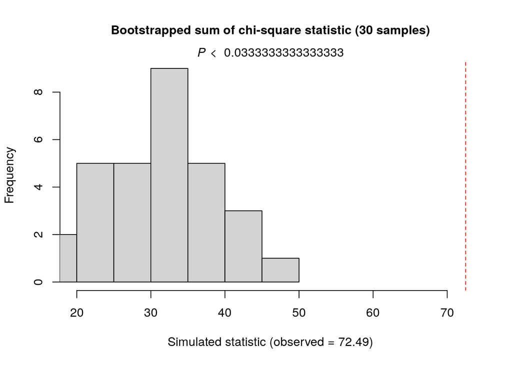

# 2 Map

```r
grid_10x10 <- st_read(paste0(wd$data,
                             "derived/VariablesSite.shp")) %>%
  transforme_carte()
```

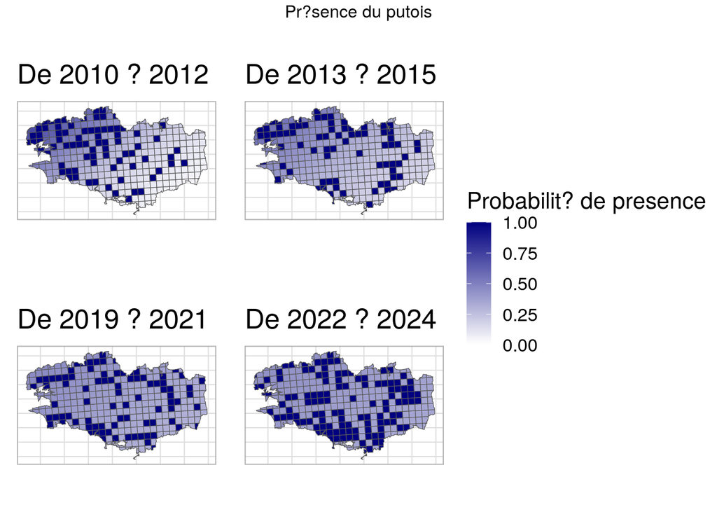

```r
rf <- unmarked::ranef(fm)
occ_prob <- unmarked::bup(rf, stat="mean")

grid_10x10 <- cbind(grid_10x10, occ_prob)

LtoM <-colorRampPalette(c('white', 'white','navy'))

g1 <- ggplot() +
  geom_sf(data = grid_10x10, aes(fill = X1))+
  labs(title="De 2010 ? 2012")+
  scale_fill_gradient2(low=LtoM(0),
                       high=LtoM(100),
                       limits = c(0, 1),
                       name = "Probabilit? de presence")+
  theme(axis.text = element_blank(),
        axis.ticks = element_blank(),
        axis.title = element_blank())


g2 <- ggplot() +
  geom_sf(data = grid_10x10, aes(fill = X2))+
  labs(title="De 2013 ? 2015")+
  scale_fill_gradient2(low=LtoM(0),
                       high=LtoM(100),
                       limits = c(0, 1),
                       name = "Probabilit? de presence")+
  theme(axis.text = element_blank(),
        axis.ticks = element_blank(),
        axis.title = element_blank())


g4 <- ggplot() +
  geom_sf(data = grid_10x10, aes(fill = X4))+
  labs(title="De 2019 ? 2021")+
  scale_fill_gradient2(low=LtoM(0),
                       high=LtoM(100),
                       limits = c(0, 1),
                       name = "Probabilit? de presence")+
  theme(axis.text = element_blank(),
        axis.ticks = element_blank(),
        axis.title = element_blank())

g5 <- ggplot() +
  geom_sf(data = grid_10x10, aes(fill = X5))+
  labs(title="De 2022 ? 2024")+
  scale_fill_gradient2(low=LtoM(0),
                       high=LtoM(100),
                       limits = c(0, 1),
                       name = "Probabilit? de presence")+
  theme(axis.text = element_blank(),
        axis.ticks = element_blank(),
        axis.title = element_blank())


plot <- ggpubr::ggarrange(g1 + theme(legend.position = "none"),
                          g2 + theme(legend.position = "none"),
                          g4 + theme(legend.position = "none"),
                          g5 + theme(legend.position = "none"),
                          common.legend = TRUE,
                          legend = "right")

ggpubr::annotate_figure(plot,
                        top = ggpubr::text_grob("Pr?sence du putois"))
```

```r
umf <- unmarkedMultFrame(
  y = detection_matrice,
  siteCovs = site_info,
  yearlySiteCovs = list(quali = quali_periodes,
                        quanti = quanti_periodes),
  numPrimary = numPrimary
)
site_info$Famille_paysage
```

[output not shown]

[output cut: 145 more lines]

```r
fm <- unmarked::colext(
  psiformula = ~ Y_10km + X_10km + Famille_paysage,     # initial occupancy
  gammaformula =  ~ 1,  # colonization
  epsilonformula = ~ 1, # extinction
  pformula = ~ 1,  # detection
  data = umf, # data
  control = list(trace = 1),
  se = TRUE)
summary(fm)
```

```
##
## Call:
## unmarked::colext(psiformula = ~Y_10km + X_10km + Famille_paysage,
##     gammaformula = ~1, epsilonformula = ~1, pformula = ~1, data = umf,
##     se = TRUE, control = list(trace = 1))
##
## Initial (logit-scale):
##                                                     Estimate     SE       z  P(>|z|)
## (Intercept)                                           -5.081 33.404 -0.1521 8.79e-01
## Y_10km                                                 0.548  0.353  1.5516 1.21e-01
## X_10km                                                -2.188  0.494 -4.4330 9.30e-06
## Famille_paysagePaysage boise et de bosquets            5.815 33.404  0.1741 8.62e-01
## Famille_paysagePaysage cultive a ragosses              6.010 33.409  0.1799 8.57e-01
## Famille_paysagePaysage cultive avec talus             13.712 19.454  0.7048 4.81e-01
## Famille_paysagePaysage de bocage a maille elargie      3.235 33.413  0.0968 9.23e-01
## Famille_paysagePaysage de bocage dense sur collines    5.386 33.417  0.1612 8.72e-01
## Famille_paysagePaysage de cultures legumieres          3.835 33.445  0.1147 9.09e-01
## Famille_paysagePaysage de littoral urbanise            6.133 33.407  0.1836 8.54e-01
##
## Colonization (logit-scale):
##  Estimate   SE     z  P(>|z|)
##    -0.964 0.17 -5.67 1.39e-08
##
## Extinction (logit-scale):
##  Estimate    SE    z  P(>|z|)
##     -1.43 0.269 -5.3 1.17e-07
##
## Detection (logit-scale):
##  Estimate     SE     z  P(>|z|)
##     -1.36 0.0821 -16.6 9.12e-62
##
## AIC: 3273.522
## Number of sites: 317
```

```r
backTransform(fm, "ext")
```

```
## Backtransformed linear combination(s) of Extinction estimate(s)
##
##  Estimate    SE LinComb (Intercept)
##     0.194 0.042   -1.43           1
##
## Transformation: logistic
```

```r
backTransform(fm, "col")
```

```
## Backtransformed linear combination(s) of Colonization estimate(s)
##
##  Estimate    SE LinComb (Intercept)
##     0.276 0.034  -0.964           1
##
## Transformation: logistic
```

On regarde ici les changement a travers le temps

```r
m1 <- nonparboot(fm,
                 B = 10)
```

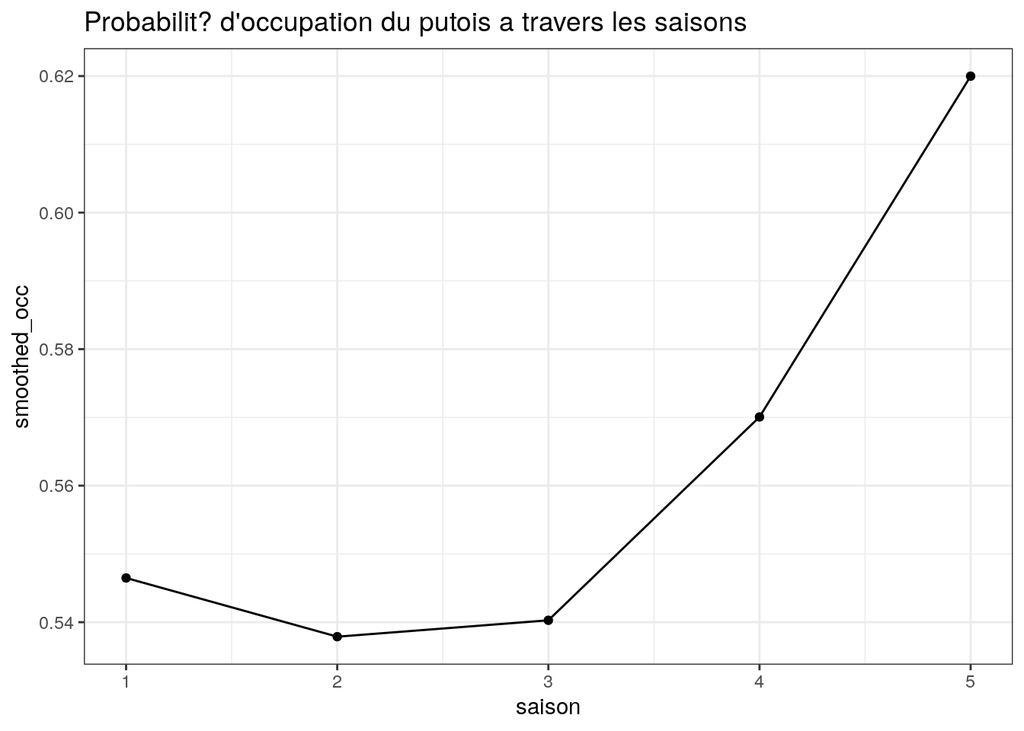

```r
predicted_occupancy <- data.frame(saison = c(1:5),
                                  smoothed_occ = smoothed(fm)[2,],
                                  SE = m1@smoothed.mean.bsse[2,])

predicted_occupancy%>%
  ggplot( aes(x=saison, y=smoothed_occ)) +
  geom_line() +
  geom_point() +
  labs(title = "Probabilit? d'occupation du putois a travers les saisons")+
  theme_bw()
```

On voit que le putois augemente, comme on a dit precedamment.